# Import and Filter TOC LEEF-1

## Read data and adjust different number of samples and cv

```r
toc <- lapply(
  data,
  function(x){
    result <- x$data[,1:max_col]
    return(result)
  }
) |> do.call(what = rbind)
toc$id <- 1:nrow(toc)
```

## Remove missing `inj_type`

We have the following measurements files with measurements without inj_type or `NULL.

```r
toc %>%
  filter(inj_type == "") %>%
  group_by(filename) %>%
  summarise(n = n()) %>%
  collect() %>%
  knitr::kable()
```

| filename | n |
| --- | --- |

These can be filtered out

```r
before <- nrow(toc)
toc <- toc %>%
  filter(inj_type != "")
after <- nrow(toc)
cat("Before : ", before, "\n")
```

```
Before :  1824
```

```r
cat("Removed: ", before - after, "\n")
```

```
Removed:  0
```

```r
cat("After  : ", after, "\n")
```

```
After  :  1824
```

## Remove Rows where `conc == 0`

Here it gets tricky. There are cases, where either `conc_1 == 0` or `conc_2 == 0`, but `conc_3 != 0`, which results in a valid measurement, i.e. `conc != 0`. I would suggest to remove all rows, in which `conc == 0`

```r
toc %>%
  filter(conc == 0) %>%
  group_by(filename) %>%
  summarise(n = n()) %>%
  collect() %>%
  knitr::kable()
```

[output not shown]

```r
before <- nrow(toc)
toc <- toc %>%
  filter(conc > 0)
after <- nrow(toc)
cat("Before : ", before, "\n")
```

```
Before :  1824
```

```r
cat("Removed: ", before - after, "\n")
```

```
Removed:  129
```

```r
cat("After  : ", after, "\n")
```

```
After  :  1695
```

## Check timestamp / id / Filename

```r
toc %>%
  select(filename, timestamp, identification, inj_type) %>%
  filter(identification != "H2O" & identification != "2.5mg/lIC") %>%
  group_by(filename, timestamp) %>%
  summarise(timestamps_count = n()) %>%
  group_by(filename) %>%
  summarise(number_of_timestamps = n()) %>%
  arrange(desc(number_of_timestamps)) %>%
  knitr::kable()
```

| filename | number_of_timestamps |
| --- | --- |
| L2_20221111A | 1 |
| L2_20221114B | 1 |
| L2_20221116A | 1 |
| L2_20221118A | 1 |
| L2_20221121A | 1 |
| L2_20221123A | 1 |
| L2_20221125A | 1 |
| L2_20221128A | 1 |
| L2_20221130A | 1 |
| L2_20221130B | 1 |
| L2_20221202A | 1 |
| L2_20221205A | 1 |
| L2_20221207A | 1 |
| L2_20221209A | 1 |

Fixed two typos in the raw data. Now, it looks OK for me.

- `LEEF_21_11_12`: “Analysis Name”,“LEEF_21_11_12 und 21_15_10A.adb”
- `LEEF_22_01_19 und 22_01_21A`: All analysis for 22_01_21 are not valid

## Set unrealistic small TC values to `NA`

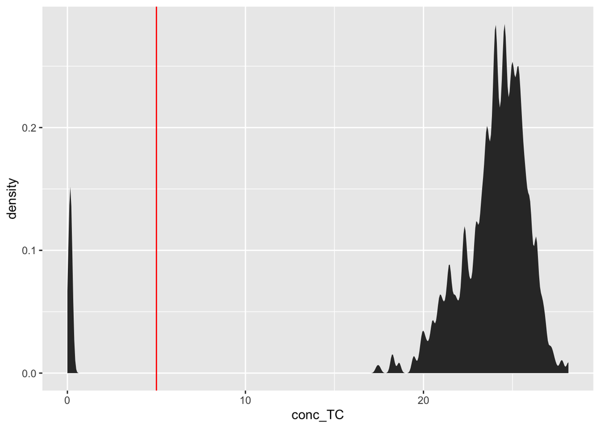

```r
tc <- toc %>%
  filter(inj_type == "TC")
tc <- data.frame(conc_TC = c(tc$conc_1, tc$conc_2, tc$conc_3))
tc %>% ggplot(aes(x=conc_TC)) +
  stat_density(bw = 0.1, na.rm = TRUE) +
  geom_vline(xintercept = 5, col = "red")
```

One can see for TC two peaks clearly separated. The values smaller than 5 will be set to `NA` as they are unrealistically low and can be linked to measuring errors in the machine.

```r
tc <- toc$inj_type == "TC"
toc$conc_1[tc & sapply(toc$conc_1 < 5, isTRUE)] <- NA
toc$conc_2[tc & sapply(toc$conc_2 < 5, isTRUE)] <- NA
toc$conc_3[tc & sapply(toc$conc_3 < 5, isTRUE)] <- NA
```

Which are now gone

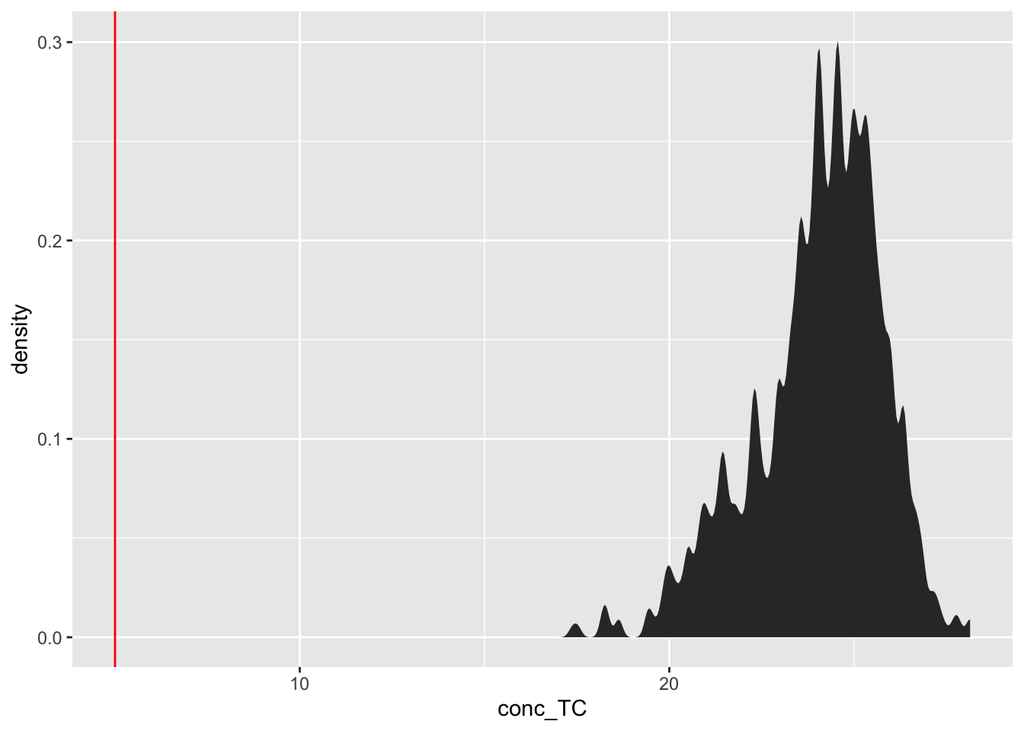

```r
tc <- toc %>%
  filter(inj_type == "TC")
tc <- data.frame(conc_TC = c(tc$conc_1, tc$conc_2, tc$conc_3))
tc %>% ggplot(aes(x=conc_TC)) +
  stat_density(bw = 0.1, na.rm = TRUE) +
  geom_vline(xintercept = 5, col = "red")
```

# Set unrealistic small IC values to `NA`

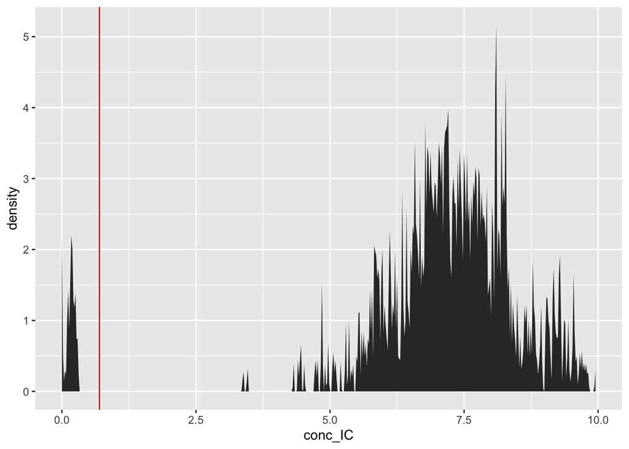

```r
tc <- toc %>%
  filter(inj_type == "IC")
tc <- data.frame(conc_IC = c(tc$conc_1, tc$conc_2, tc$conc_3))
tc %>% ggplot(aes(x=conc_IC)) +
  geom_vline(xintercept = 0.7, col = "red") +
  stat_density(bw = 0.001, na.rm = TRUE)
```

```r
tc <- toc$inj_type == "IC"
toc$conc_1[tc & sapply(toc$conc_1 < 0.7, isTRUE)] <- NA
toc$conc_2[tc & sapply(toc$conc_2 < 0.7, isTRUE)] <- NA
toc$conc_3[tc & sapply(toc$conc_3 < 0.7, isTRUE)] <- NA
```

Which are now gone

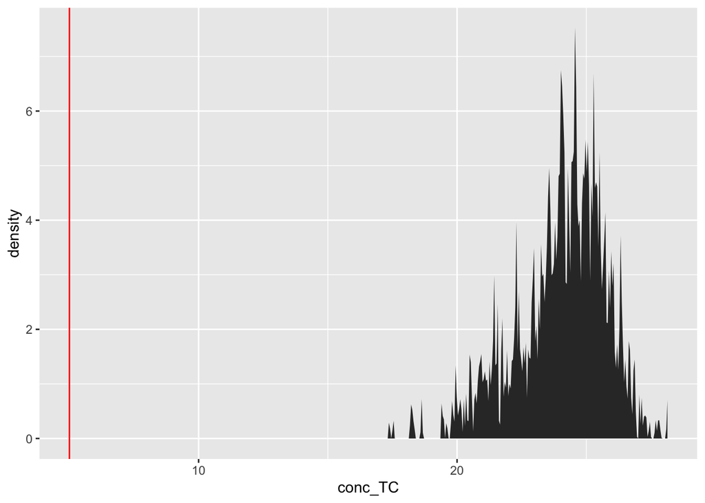

```r
tc <- toc %>%
  filter(inj_type == "TC")
tc <- data.frame(conc_TC = c(tc$conc_1, tc$conc_2, tc$conc_3))
tc %>% ggplot(aes(x=conc_TC)) +
  stat_density(bw = 0.001, na.rm = TRUE) +
  geom_vline(xintercept = 5, col = "red")
```

## Recalculate `conc` and TOC

In addition, we have calculate the TOC, which is `TOC = TC - IC`

### Calculate `conc`

```r
cvf <- function(x, y){
  sapply(
    1:length(x),
    function(i){
      sd(c(x[i], y[i])) / mean(c(x[i], y[i])) * 100
    }
  )
}


toc$cv_12 <- cvf(toc$conc_1, toc$conc_2)
toc$cv_13 <- cvf(toc$conc_1, toc$conc_3)
toc$cv_23 <- cvf(toc$conc_2, toc$conc_3)

toc$conc_12 <- rowMeans(toc[,c("conc_1", "conc_2")])
toc$conc_13 <- rowMeans(toc[,c("conc_1", "conc_3")])
toc$conc_23 <- rowMeans(toc[,c("conc_2", "conc_3")])



toc$conc <- apply(
  toc,
  1,
  function(x){
    if (isTRUE(as.numeric(x[["cv_12"]]) < max_cv)) {
      return(mean(as.numeric(x[["conc_1"]]), as.numeric(x[["conc_2"]])))
    } else {
      sel <- suppressWarnings( which(x == min(as.numeric(x[["cv_12"]]), as.numeric(x[["cv_13"]]), as.numeric(x[["cv_23"]]), na.rm = TRUE)) )
      if (length(sel) == 0) {return(NA)}
      if (sel == 1) {return(mean(as.numeric(x[["conc_1"]]), as.numeric(x[["conc_2"]])))}
      if (sel == 2) {return(mean(as.numeric(x[["conc_1"]]), as.numeric(x[["conc_3"]])))}
      if (sel == 3) {return(mean(as.numeric(x[["conc_2"]]), as.numeric(x[["conc_3"]])))} else {return(NA)}
    }
  }
)
```

### Calculate TOC

```r
i <- which(toc$inj_type == "TOC")
toc$conc[i] <- NA

TOC_calc <- toc %>%
  mutate(an_id = paste(filename, position)) %>%
  pivot_wider(id_cols = an_id, names_from = inj_type, values_from = conc) %>%
  mutate(TOC_calc = TC - IC) %>%
  select(an_id, TOC_calc) %>%
  mutate(an_id = paste(an_id, "TOC"))

toc <- toc %>%
  mutate(an_id = paste(filename, position, inj_type)) %>%
  left_join(TOC_calc, by = "an_id") %>%
  mutate( conc = ifelse(inj_type == "TOC", TOC_calc, conc) ) %>%
  select( -TOC_calc, -an_id)
```

And the plot again after re-calculation of the TOC values

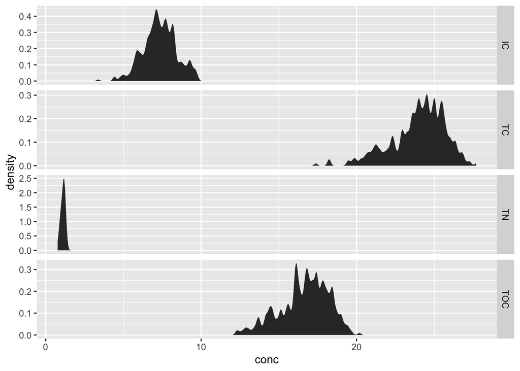

```r
toc %>%
  ggplot(aes(x=conc)) +
  stat_density(bw = 0.1, na.rm = TRUE) +
  facet_grid(rows = vars(inj_type), scales = "free_y")
```

## Add to database

The toc is now added to the database

```r
add_to_and_overwrite_table_in_RRD(toc = toc, dbname = db, overwrite = TRUE)
```

```
[1] 0
```

```r
toc_original <- toc

toc$id <- 1:nrow(toc)
```

## Plot after filtering

Now let’s look at the plots of the measurements per bottle per timestep

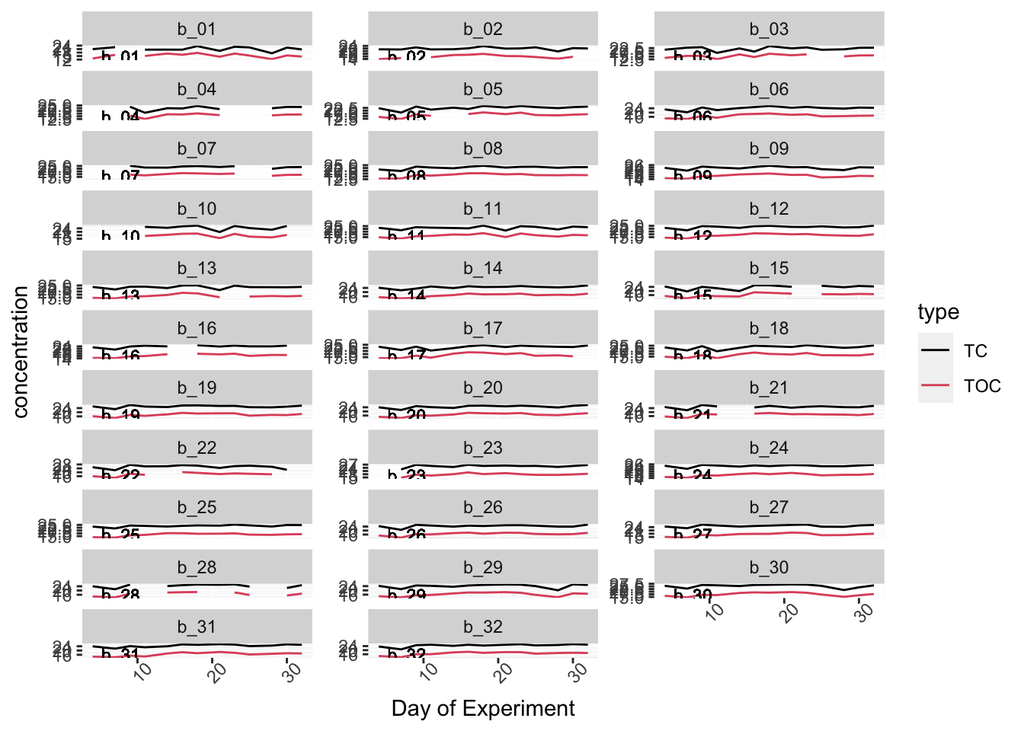

```r
if (params$LEEF == "LEEF_1") {
  p1 <- plot_tocs_per_bottle_per_timestamp(db = db, c("TC", "TOC"))
  p2 <- plot_tocs_per_bottle_per_timestamp(db = db, c("IC"))
  p3 <- plot_tocs_per_bottle_per_timestamp(db = db, c("TN"))
} else {
  p1 <- LEEF_2_plot_tocs_per_bottle_per_timestamp(db = db, c("TC", "TOC"))
  p2 <- LEEF_2_plot_tocs_per_bottle_per_timestamp(db = db, c("IC"))
  p3 <- LEEF_2_plot_tocs_per_bottle_per_timestamp(db = db, c("TN"))
}
p1
```

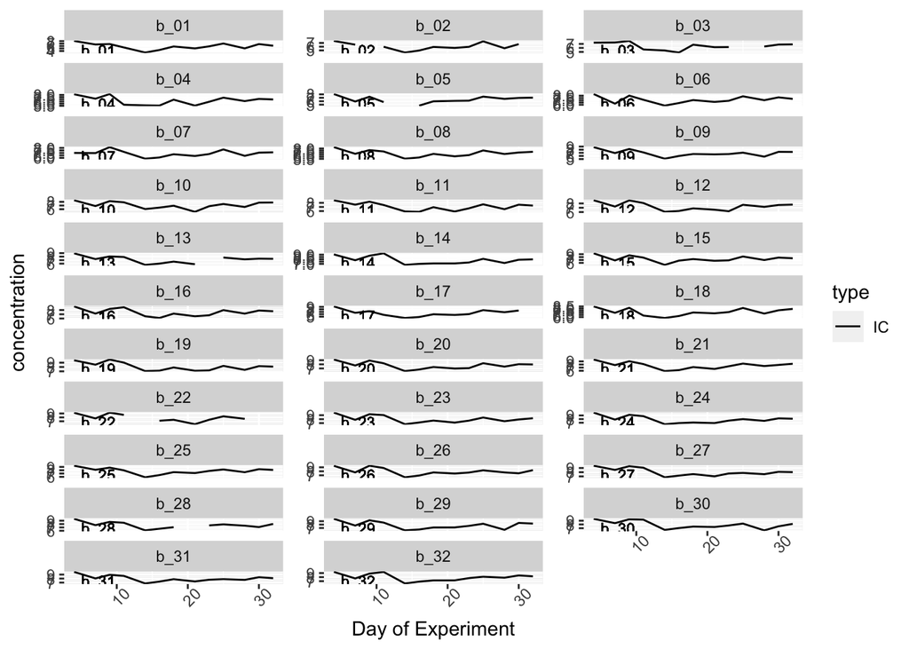

```r
p2
```

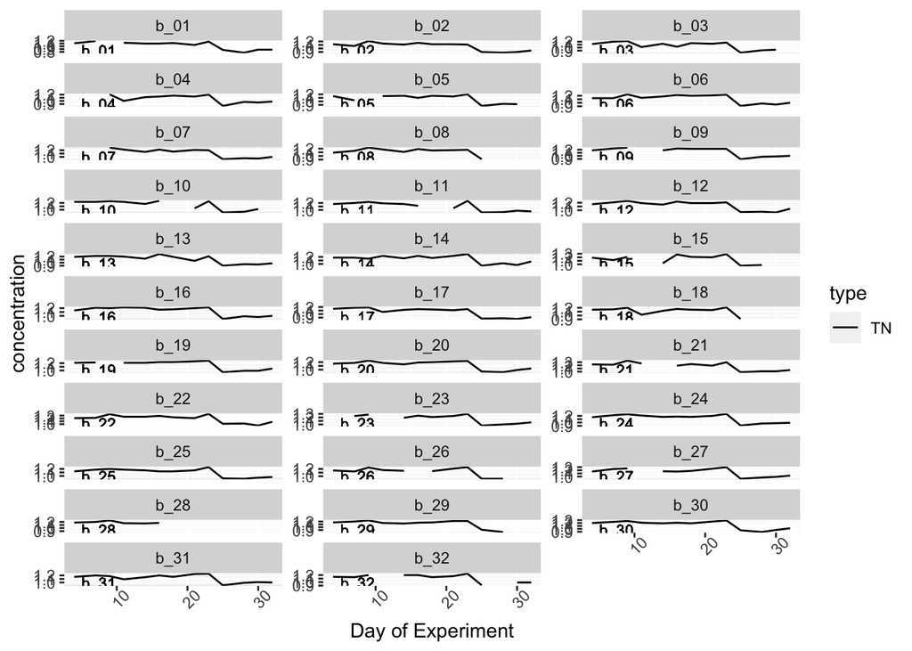

```r
p3
```

## Number of measurements per `timestamp`, `bottle` and `inj_type`

We have to look if there are any duplicate measurements.

```r
dupl <- toc %>%
  group_by(timestamp, bottle, inj_type) %>%
  filter(!is.na(bottle)) %>%
  summarise(fn_1 = min(filename), fn_2 = max(filename), count = n(), min_conc = min(conc), max_conc = max(conc)) %>%
  filter(count > 1 & count < 10) %>%
  mutate(diff = max_conc - min_conc) %>%
  arrange(inj_type, diff)
dupl %>%
  group_by(fn_1, fn_2, timestamp) %>%
  summarise() %>%
  arrange(timestamp) %>%
  knitr::kable()
```

| fn_1 | fn_2 | timestamp |
| --- | --- | --- |
| L2_20221114B | L2_20221202A | NA |

And some plots of the duplicate concentration values only

```r
dat <- db_read_toc(db = db, duplicates = NULL) %>%
  collect()
if (nrow(dat) > 0){
dat$id <- 1:nrow(dat)
ids <- dat %>%
  filter(!is.na(bottle)) %>%
  group_by(timestamp, bottle, type) %>%
  summarize(min(id), max(id), n = n()) %>%
  filter(n > 1)
ids <- c(ids$`min(id)`, ids$`max(id)`) |>
  unique()
x <- dat %>%
  filter(id %in% ids) %>%
  group_by(day, timestamp, bottle, type) %>%
  summarise(timestamp, bottle, type, mic = min(concentration), mac = max(concentration)) %>%
  mutate(mdiff = mac - mic)
}
```

### TN Duplicates

```r
if (nrow(x) > 0){
  pl <- x %>%
    filter(type == "TN") %>%
    ggplot2::ggplot(ggplot2::aes(x = mic, y = mac, colour = type)) +
    ggplot2::geom_point() +
    ggplot2::xlab("Smaler concentration Value") +
    ggplot2::ylab("Larger concentration Value")

  ggMarginal(pl, type="histogram")
}
```

### TC Duplicates

```r
if (nrow(x) > 0){
  pl <- x %>%
    filter(type == "TC") %>%
    ggplot2::ggplot(ggplot2::aes(x = mic, y = mac, colour = type)) +
    ggplot2::geom_point() +
    ggplot2::xlab("Smaler concentration Value") +
    ggplot2::ylab("Larger concentration Value")

  ggMarginal(pl, type="histogram")
}
```

### IC Duplicates

```r
if (nrow(x) > 0){
  pl <- x %>%
    filter(type == "IC") %>%
    ggplot2::ggplot(ggplot2::aes(x = mic, y = mac, colour = type)) +
    ggplot2::geom_point() +
    ggplot2::xlab("Smaler concentration Value") +
    ggplot2::ylab("Larger concentration Value")

  ggMarginal(pl, type="histogram")
}
```

### TOC Duplicates

```r
if (nrow(x) > 0){
  pl <- x %>%
    filter(type == "TOC") %>%
    ggplot2::ggplot(ggplot2::aes(x = mic, y = mac, colour = type)) +
    ggplot2::geom_point() +
    ggplot2::xlab("Smaler concentration Value") +
    ggplot2::ylab("Larger concentration Value")

  ggMarginal(pl, type="histogram")
}
```

### Final diagnostic report

```r
try(
  report_diagnostic(
    db = params$db,
    template = params$LEEF,
    suffix = "TOC_added",
    format = "html"
  )
)
```

```
processing file: DiagnosticReport.Rmd
```

[output not shown]